# base R

Ein Vergleich mit dem Tidyverse

Autor:in

Zugehörigkeit

Daniela Palleschi

Humboldt-Universität zu Berlin

Veröffentlichungsdatum

24. Januar 2024

# 1 Lesungen

- [Kapital 27 (A field guide to base R)](https://r4ds.hadley.nz/base-r) in Wickham et al. (2023)
- Kurs-Website: [Kap. 12: base R](https://daniela-palleschi.github.io/r4ling/mats/12-baseR.html)

# Lernziele

Heute werden wir…

- lernen, was base R ist
- Base R und Tidyverse vergleichen
- die Base-R-Äquivalente der Tidyverse-Verben kennenlernen

# 2 base R

- Basissoftware, die die Programmiersprache R enthält
  - enthält das Paket `base`, das zum Ausführen von R erforderlich ist
- enthält mehrere Pakete wie `utils` und `stats` (neben anderen)
  - wird installiert, wenn Sie R installieren

## 2.1 tidyverse

- das [Tidyverse](https://www.tidyverse.org/) (Wickham et al., 2019a) ist eine Familie von R-Paketen, die das Bereinigen und Verwirren von Daten erleichtern sollen
  - tidyverse-Pakete “haben eine gemeinsame Designphilosophie und eine gemeinsame Grammatik und Datenstruktur, so dass das Erlernen eines Pakets das Erlernen des nächsten erleichtert.” (Wickham et al., 2019b). - tidyverse wurde in der Programmiersprache R geschrieben

## 2.2 base R vs. tidyverse

- Hauptziel von base R ist Stabilität
  - nicht viele oder häufige Änderungen an der Funktionalität der Funktionen
- tidyverse fügt ständig Funktionen hinzu, aktualisiert sie und ändert sie
- das bedeutet, dass der Code von tidyverse anfällig für “Brüche” ist: tidyverse-Code, der heute läuft, läuft vielleicht in ein paar Jahren nicht mehr, wenn einige Funktionen oder Argumente “veraltet” sind

## 2.3 Kontroverse

- einige Leute bevorzugen die Verwendung von Base R oder Tidyverse
  - Argumente für tidyverse: besser lesbar, aufgeräumter, einfacher für Nicht-Programmierer
  - Argumente für base R: “wahrere” R-Programmierung, stabiler
- Im Allgemeinen ist es ratsam, eine gute Kenntnis der einen und zumindest Grundkenntnisse der anderen Methode zu haben.

### 2.3.1 Twitter-Debatten

> What a thing to say when modern R is pretty much synonymous with the tidyverse for many in the community!  
> I was a base R masochist once too.. but there's no need for statements like this when the tidyverse has helped so many of us be more productive and write more readable code.

## 2.4 Meine Vorliebe

- Ich denke natürlich, dass das Erlernen des Tidyverse wichtig ist
  - das Tidyverse ist menschenzentriert, und wir sind keine Programmierer oder Informatiker
- nicht jeder stimmt mir zu, aber es gibt auch viele Leute, die mir zustimmen

# 3 Set-up

```r
pacman::p_load(
  tidyverse,
  here
)
```

## 3.1 Daten einlesen

- Jetzt sehen wir unseren ersten Vergleich zwischen dem tidyverse-Code und dem Basis-R-Code

## 3.2 CSV: tidyverse

```
tidyverse
```

```r
df_tidy <-
  read_csv(
    here("daten", "languageR_english.csv")
  )
```

## 3.3 CSV: base R

```
base R
```

```r
df_base <-
  read.csv(
    here("daten", "languageR_english.csv")
  )
```

## 3.4 Vergleich der Ergebnisse

- wie viele Spalten?

```r
length(df_tidy)
```

```
[1] 7
```

```r
length(df_base)
```

```
[1] 7
```

- Wie lauten die Spaltennamen?

```r
names(df_base)
```

```
[1] "AgeSubject"       "Word"             "LengthInLetters"  "WrittenFrequency"
[5] "WordCategory"     "RTlexdec"         "RTnaming"
```

```r
names(df_tidy)
```

```
[1] "AgeSubject"       "Word"             "LengthInLetters"  "WrittenFrequency"
[5] "WordCategory"     "RTlexdec"         "RTnaming"
```

- wie viele Zeilen?

```r
nrow(df_tidy)
```

```
[1] 4568
```

```r
nrow(df_base)
```

```
[1] 4568
```

- die Datenstruktur ist identisch

# 4 Mit Spalten und Zeilen hantieren

- sehen wir uns die Basis-R-Alternativen zu den gebräuchlichsten `dplyr`-Verben an

## 4.1 Variablen extrahieren: tidyverse

```
tidyverse
```

```r
df_tidy |>
  select(AgeSubject)
```

```
# A tibble: 10 × 1
   AgeSubject
   <chr>
 1 young
 2 young
 3 young
 4 young
 5 young
 6 young
 7 young
 8 young
 9 young
10 young
```

## 4.2 Variablen extrahieren: base R

- das Dollarzeichen (`$`) kann verwendet werden, um eine Spalte aus einem Datenrahmen (oder Tibble) zu extrahieren
- dies ergibt einen Vektor, während `dplyr::select()` die Datenrahmen-/Tibble-Attribute der Spalte beibehält

```
base R
```

```r
df_base$AgeSubject
```

```
 [1] "young" "young" "young" "young" "young" "young" "young" "young" "young"
[10] "young" "young" "young" "young" "young" "young" "young" "young" "young"
```

## 4.3 Variablen extrahieren: base R

- oder wir können `Datenrahmen[Zeile,Spalte]` verwenden
- wir können den Namen einer Spalte in Anführungszeichen setzen

```
base R
```

```r
# using variable name
df_base[,"AgeSubject"]
```

```
 [1] "young" "young" "young" "young" "young" "young" "young" "young" "young"
[10] "young" "young" "young" "young" "young" "young" "young" "young" "young"
```

- oder wir können den Index der Spalte angeben, wobei 1 für die erste Spalte steht, 2 für die zweite Spalte und so weiter

```
base R
```

```r
# using variable index
df_base[,1]
```

```
 [1] "young" "young" "young" "young" "young" "young" "young" "young" "young"
[10] "young" "young" "young" "young" "young" "young" "young" "young" "young"
```

## 4.4 Mehrere Variablen: tidyverse

```
tidyverse
```

```r
df_tidy |>
  select(AgeSubject, RTlexdec)
```

```
# A tibble: 10 × 2
   AgeSubject RTlexdec
   <chr>         <dbl>
 1 young          695.
 2 young          600.
 3 young          547.
 4 young          617.
 5 young          633.
 6 young          687.
 7 young          584.
 8 young          527.
 9 young          741.
10 young          536.
```

## 4.5 Mehrere Variablen: baseR

- dafür brauchen wir `c()`

```
base R
```

```r
# using variable name
df_base[,c("AgeSubject", "RTlexdec")]
```

```
   AgeSubject RTlexdec
1       young   694.89
2       young   600.40
3       young   547.27
4       young   616.60
5       young   633.08
6       young   686.75
7       young   584.40
8       young   526.82
9       young   741.48
10      young   536.38
```

```
base R
```

```r
# using variable index
df_base[,c(1, 6)]
```

```
   AgeSubject RTlexdec
1       young   694.89
2       young   600.40
3       young   547.27
4       young   616.60
5       young   633.08
6       young   686.75
7       young   584.40
8       young   526.82
9       young   741.48
10      young   536.38
```

## 4.6 Extrahieren/Filtern von Beobachtungen: tidyverse

- mit der Funktion `filter()` von `dplyr`

```
tidyverse
```

```r
df_tidy |>
  filter(RTlexdec > 600 & RTnaming < 480)
```

```
# A tibble: 856 × 7
   AgeSubject Word  LengthInLetters WrittenFrequency WordCategory RTlexdec
   <chr>      <chr>           <dbl>            <dbl> <chr>           <dbl>
 1 young      doe                 3             3.91 N                695.
 2 young      pork                4             5.02 N                617.
 3 young      prop                4             4.77 N                687.
 4 young      arc                 3             4.89 N                741.
 5 young      tile                4             4.08 N                647.
 6 young      slope               5             5.80 N                633.
 7 young      pith                4             2.48 N                696.
 8 young      blitz               5             4.19 N                672.
 9 young      port                4             6.08 N                683.
10 young      plan                4             7.46 N                636.
# ℹ 846 more rows
# ℹ 1 more variable: RTnaming <dbl>
```

## 4.7 Extrahieren/Filtern von Beobachtungen: base R

- fügen Sie diese bedingten Anweisungen in `[,]` ein
  - wir müssen den Datenrahmennamen mit dem Dollarzeichen vor dem Spaltennamen einschließen

```
base R
```

```r
df_base[df_base$RTlexdec > 600 & df_base$RTnaming < 480,]
```

```
   AgeSubject  Word LengthInLetters WrittenFrequency WordCategory RTlexdec
1       young   doe               3         3.912023            N   694.89
4       young  pork               4         5.017280            N   616.60
6       young  prop               4         4.770685            N   686.75
9       young   arc               3         4.890349            N   741.48
17      young  tile               4         4.077537            N   647.07
18      young slope               5         5.802118            N   632.54
22      young  pith               4         2.484907            N   695.86
26      young blitz               5         4.189655            N   671.59
29      young  port               4         6.084499            N   683.36
34      young  plan               4         7.462789            N   636.10
   RTnaming
1     466.4
4     460.3
6     477.1
9     453.8
17    459.3
18    476.2
22    473.3
26    469.5
29    459.3
34    470.4
```

## 4.8 Einzelne Datenpunkte auswählen: tidyverse

- Filter()`und Select()` verwenden (was wir schon vorher gemacht haben)

```
tidyverse
```

```r
df_tidy |>
  filter(RTlexdec > 600, RTnaming < 480) |>
  select(AgeSubject, RTlexdec)
```

```
# A tibble: 10 × 2
   AgeSubject RTlexdec
   <chr>         <dbl>
 1 young          695.
 2 young          617.
 3 young          687.
 4 young          741.
 5 young          647.
 6 young          633.
 7 young          696.
 8 young          672.
 9 young          683.
10 young          636.
```

## 4.9 Einzelne Datenpunkte auswählen: base R

- Zeilen- und Spaltenwerte in `[,]` kombinieren

```
base R
```

```r
df_base[df_base$RTlexdec > 600 & df_base$RTnaming < 480,c("AgeSubject", "RTlexdec")]
```

```
   AgeSubject RTlexdec
1       young   694.89
4       young   616.60
6       young   686.75
9       young   741.48
17      young   647.07
18      young   632.54
22      young   695.86
26      young   671.59
29      young   683.36
34      young   636.10
```

## 4.10 Einzelne Datenpunkte auswählen: base R

- Auch hier können Sie die Spaltennamen durch den Indexwert ersetzen

```
base R
```

```r
df_base[df_base$RTlexdec > 600 & df_base$RTnaming < 480,c(1, 6)]
```

```
   AgeSubject RTlexdec
1       young   694.89
4       young   616.60
6       young   686.75
9       young   741.48
17      young   647.07
18      young   632.54
22      young   695.86
26      young   671.59
29      young   683.36
34      young   636.10
```

## 4.11 Neue Variablen erstellen: tidyverse

- mit der Funktion `mutate()` von `dplyr`

```
tidyverse
```

```r
df_tidy |>
  mutate(rt_lexdec_s = RTlexdec/1000)
```

```
# A tibble: 4,568 × 8
   AgeSubject Word   LengthInLetters WrittenFrequency WordCategory RTlexdec
   <chr>      <chr>            <dbl>            <dbl> <chr>           <dbl>
 1 young      doe                  3             3.91 N                695.
 2 young      whore                5             4.52 N                600.
 3 young      stress               6             6.51 N                547.
 4 young      pork                 4             5.02 N                617.
 5 young      plug                 4             4.89 N                633.
 6 young      prop                 4             4.77 N                687.
 7 young      dawn                 4             6.38 N                584.
 8 young      dog                  3             7.16 N                527.
 9 young      arc                  3             4.89 N                741.
10 young      skirt                5             5.93 N                536.
# ℹ 4,558 more rows
# ℹ 2 more variables: RTnaming <dbl>, rt_lexdec_s <dbl>
```

- Definieren Sie den Namen der neuen Variable (mit `dataframe$variable`) und weisen Sie den Wert mit dem Zuweisungsoperator `<-` zu

```
base R
```

```r
df_base$rt_lexdec_s <- df_base$RTlexdec/1000
```

## 4.13 Zusammenfassen: tidyverse

- `Zusammenfassen()` von `dplyr`

```
tidyverse
```

```r
  df_tidy |>
  summarise(
    mean_lexdec = mean(RTlexdec),
    sd_lexdec = sd(RTlexdec),
    mean_naming = mean(RTnaming, na.rm = T),
    sd_naming = sd(RTnaming, na.rm = T)
  )
```

```
# A tibble: 1 × 4
  mean_lexdec sd_lexdec mean_naming sd_naming
        <dbl>     <dbl>       <dbl>     <dbl>
1        708.      115.        566.      101.
```

- wir müssen neue Objekte erstellen, die den Wert jeder Operation enthalten, und sie mit der Funktion “data.frame()” zu einem Datenrahmen zusammenfassen
- Es gibt viele alternative Möglichkeiten, dies zu tun, aber dies ist die einfachste, wenn wir nur ein paar zusammenfassende Statistiken erstellen wollen

```
base R
```

```r
data.frame(mean_lexdec = mean(df_base$RTlexdec),
           sd_lexdec = sd(df_base$RTlexdec),
           mean_naming = mean(df_base$RTnaming, na.rm = T),
           sd_naming = sd(df_base$RTnaming, na.rm = T))
```

```
  mean_lexdec sd_lexdec mean_naming sd_naming
1    708.1336  114.8599    565.9233  100.8153
```

# 5 Plots

- `ggplot2` ist auch bei Leuten beliebt, die tidyverse nicht benutzen
  - das liegt daran, dass es einige nützliche Funktionen und ein sauberes Aussehen hat

## 5.1 Plots: base R

- kann nützlich sein, wenn Sie einfache Diagramme erstellen wollen, um einen ersten Blick auf Ihre Daten zu erhalten
  - Die nützlichsten Funktionen sind “hist()” und “plot()”.
  - Beachten Sie, dass diese Funktionen mit Vektoren arbeiten, weshalb wir `$` verwenden müssen, um die Spalten aus dem Datenrahmen zu extrahieren.

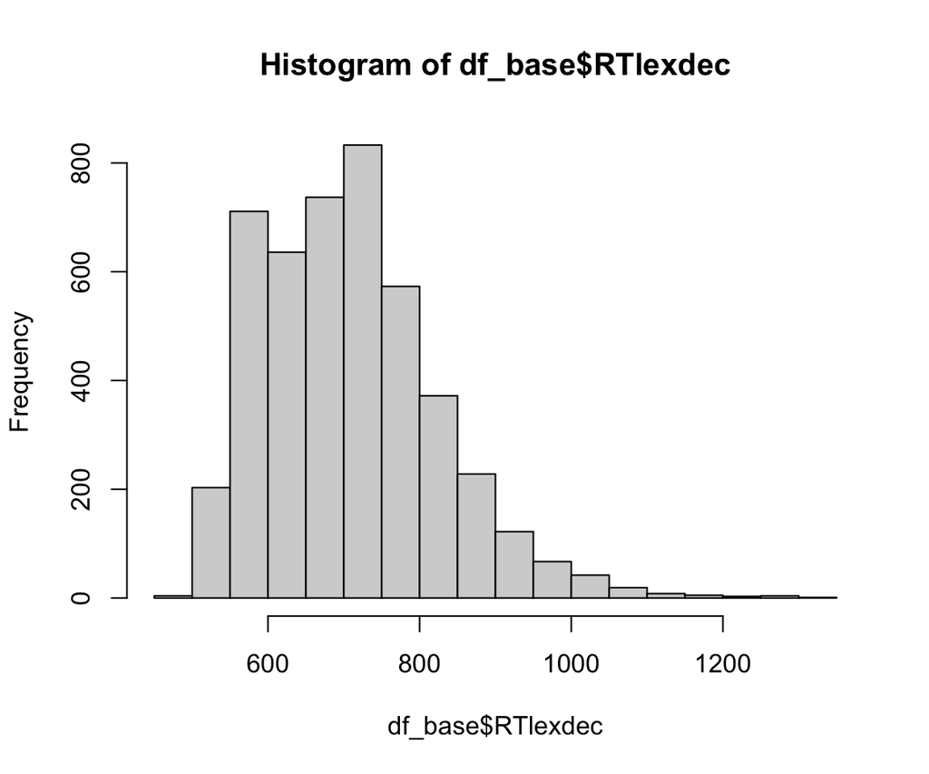

```r
hist(df_base$RTlexdec)
```

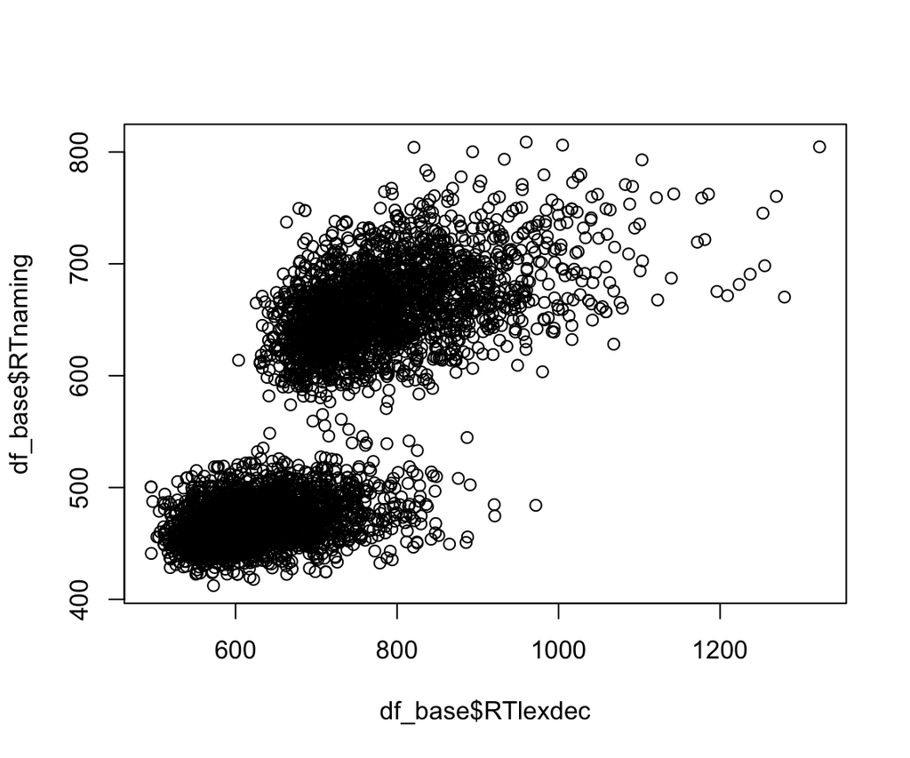

```r
plot(df_base$RTlexdec, df_base$RTnaming)
```

## 5.2 Plots: tidyverse

- wie wir es schon gesehen haben:

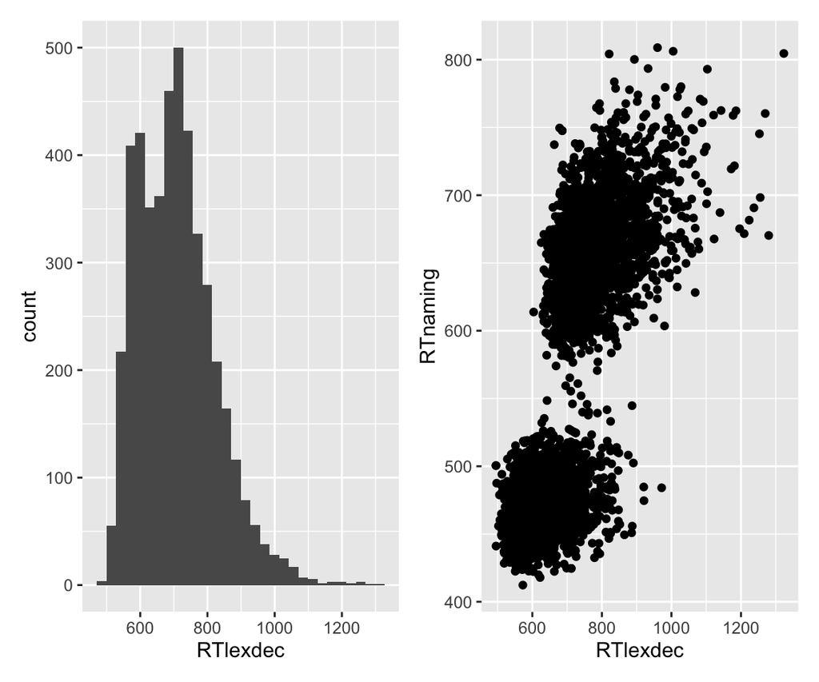

Abbildung 1: Histogram and scatterplot with ggplot2

```r
library(patchwork)

# histogram
fig_hist <-
  df_base |>
  ggplot() +
  aes(x = RTlexdec) +
  geom_histogram()

# scatter plot
fig_scatter <-
  df_base |>
  ggplot() +
  aes(x = RTlexdec, y = RTnaming) +
  geom_point()

fig_hist + fig_scatter
```

# Lernziele 🏁

Heute haben wir…

- gelernt, was Base R ist ✅
- Base R und Tidyverse verglichen ✅
- lernen die Base R-Entsprechungen gängiger Tidyverse-Verben ✅

# 6 Aufgaben

Konvertieren Sie den folgenden tidyverse-Code in Base R. Wir werden wieder den Datensatz “languageR_english.csv” verwenden.

## 6.1 Daten einlesen

```r
df_eng <-
  read_csv(here("daten", "languageR_english.csv"))
```

## 6.2 Extrahieren von Spalten

```r
df_eng |>
  select(Word, WrittenFrequency)
```

```
# A tibble: 10 × 2
   Word   WrittenFrequency
   <chr>             <dbl>
 1 doe                3.91
 2 whore              4.52
 3 stress             6.51
 4 pork               5.02
 5 plug               4.89
 6 prop               4.77
 7 dawn               6.38
 8 dog                7.16
 9 arc                4.89
10 skirt              5.93
```

## 6.3 Zeilen filtern

```r
df_eng |>
  filter(WrittenFrequency > 5.6)
```

```
# A tibble: 10 × 7
   AgeSubject Word   LengthInLetters WrittenFrequency WordCategory RTlexdec
   <chr>      <chr>            <dbl>            <dbl> <chr>           <dbl>
 1 young      stress               6             6.51 N                547.
 2 young      dawn                 4             6.38 N                584.
 3 young      dog                  3             7.16 N                527.
 4 young      skirt                5             5.93 N                536.
 5 young      are                  3            11.3  N                611.
 6 young      pipe                 4             6.00 N                563.
 7 young      guard                5             6.59 N                559.
 8 young      slope                5             5.80 N                633.
 9 young      pile                 4             6.16 N                595.
10 young      tide                 4             6.08 N                598.
# ℹ 1 more variable: RTnaming <dbl>
```

## 6.4 Filterung von Zeilen und Extraktion von Spalten

```r
df_eng |>
  filter(WrittenFrequency > 5.6 & AgeSubject == "old") |>
  select(AgeSubject, Word, WrittenFrequency)
```

```
# A tibble: 10 × 3
   AgeSubject Word   WrittenFrequency
   <chr>      <chr>             <dbl>
 1 old        stress             6.51
 2 old        dawn               6.38
 3 old        dog                7.16
 4 old        skirt              5.93
 5 old        are               11.3
 6 old        pipe               6.00
 7 old        guard              6.59
 8 old        slope              5.80
 9 old        pile               6.16
10 old        tide               6.08
```

## 6.5 Streudiagramm

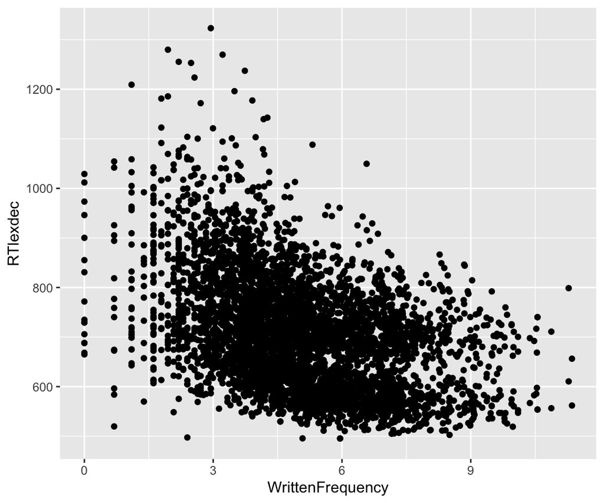

```r
df_eng |>
  ggplot() +
  aes(x = WrittenFrequency, y = RTlexdec) +
  geom_point()
```

## 6.6 Tidyverse versus Basis-R

Wie ist Ihr Eindruck von Base R im Vergleich zu Tidyverse? Würden Sie, basierend auf dem, was Sie gesehen haben, das eine dem anderen vorziehen, oder würden Sie das eine nur in bestimmten Fällen vorziehen? Hier gibt es keine richtige Antwort.

# Session Info

Hergestellt mit R version 4.3.0 (2023-04-21) (Already Tomorrow) und RStudioversion 2023.9.0.463 (Desert Sunflower).

# Literaturverzeichnis

Wickham, H., Averick, M., Bryan, J., Chang, W., McGowan, L. D., François, R., Grolemund, G., Hayes, A., Henry, L., Hester, J., Kuhn, M., Pedersen, T. L., Miller, E., Bache, S. M., Müller, K., Ooms, J., Robinson, D., Seidel, D. P., Spinu, V., … Yutani, H. (2019a). Welcome to the tidyverse. *Journal of Open Source Software*, *4*(43), 1686. https://doi.org/10.21105/joss.01686

Wickham, H., Averick, M., Bryan, J., Chang, W., McGowan, L., François, R., Grolemund, G., Hayes, A., Henry, L., Hester, J., Kuhn, M., Pedersen, T., Miller, E., Bache, S., Müller, K., Ooms, J., Robinson, D., Seidel, D., Spinu, V., … Yutani, H. (2019b). Welcome to the Tidyverse. *Journal of Open Source Software*, *4*(43), 1686. https://doi.org/10.21105/joss.01686

Wickham, H., Çetinkaya-Rundel, M., & Grolemund, G. (2023). *R for Data Science* (2. Aufl.).

Winter, B. (2019). Statistics for Linguists: An Introduction Using R. In *Statistics for Linguists: An Introduction Using R*. Routledge. https://doi.org/10.4324/9781315165547